# Lab 10 — the theory: YOLO and hyperparameter optimization

Machine Learning (MPA-MLR)

## 1 · YOLO from scratch

> Which cell learns an object whose box crosses several cells?

## Where the grid comes from

[figure not shown]

- **Four 2× poolings:** 96 → 6, so one output position = one **16 px cell**
- **1 × 1 convolution** → **13 channels** = $5B + C$: $B = 2$ **boxes** per cell × 5 numbers + $C = 3$ **classes**
- Receptive field **110 px**: a cell **sees far beyond its patch**, but answers only for it

## The grid and the responsible cell

[figure not shown]

- **Responsible cell** = the cell with the **centre** — column $\lfloor c_x/16 \rfloor$, row $\lfloor c_y/16 \rfloor$
- $x, y$ relative to the **cell**, in $[0, 1)$; $w, h$ relative to the **image**

## Target tensor and output tensor

[figure not shown]

- **Target** $S \times S \times (5 + C) = 6 \times 6 \times 8$
  - one box per cell, zeros elsewhere
  - $S = 6$: the grid · $C = 3$: the classes
- **Your choice:** $B$ and $S$; $C$ is given by the data
- **Output** $S \times S \times (5B + C) = 6 \times 6 \times 13$
  - $B = 2$ **boxes per cell**, each $x, y, \sqrt w, \sqrt h, c$
  - **one** class distribution per cell, shared by both boxes

## The responsible box

[figure not shown]

**Two boxes** in the object’s cell:

- the one that **fits better** (larger IoU) learns the box
- the **other** one only learns $c \to 0$

## The YOLOv1 loss

Four sums of **squared errors**, averaged over the batch.

| Term | Which predictions? | Target | Weight |
| --- | --- | --- | --- |
| **Box** | Responsible box | $x, y, \sqrt w, \sqrt h$ | $\lambda_{\text{coord}} = 5$ |
| **Confidence** | Responsible box | IoU with its true box | 1 |
| **Confidence** | Every other box | Zero | $\lambda_{\text{noobj}} = 0.5$ |
| **Class** | Each occupied cell | One-hot class | 1 |

**Check (1b):** one object, $c = 0.5$ everywhere → unweighted no-object sum $71 \times 0.5^2 = 17.75$

$$\begin{aligned}
L = {} & \lambda_\text{coord} \sum_{i,j} \mathbb 1^{\text{obj}}_{ij} \left[(x_{ij} - \hat x_i)^2 + (y_{ij} - \hat y_i)^2 + (\sqrt{w_{ij}} - \sqrt{\hat w_i})^2 + (\sqrt{h_{ij}} - \sqrt{\hat h_i})^2\right] \\
& + \sum_{i,j} \mathbb 1^{\text{obj}}_{ij} \left(c_{ij} - \mathrm{IoU}_{ij}\right)^2
+ \lambda_\text{noobj} \sum_{i,j} \mathbb 1^{\text{noobj}}_{ij}\, c_{ij}^2
+ \sum_{i \in \text{obj}} \sum_{k=1}^{C} \left(p_{ik} - \hat p_{ik}\right)^2
\end{aligned}$$

## Decoding: from 6 × 6 × 13 to boxes

[figure not shown]

- **Corners** = centre ∓ half the width and height
- The figure decodes **one** box. Every one of the 36 cells does this for **both** its boxes → $6 \cdot 6 \cdot 2 =$ **72 candidate boxes** per image

## Box IoU and NMS

[figure not shown]

- intersection: **max** of the left/top edges, **min** of the right/bottom ones, clamp at 0
- $\mathrm{IoU} = \dfrac{12}{24 + 30 - 12} \approx 0.29$
- **NMS:** sort by score → **keep** the best → **remove** IoU > 0.5 with it → repeat
- 0.90 kept, 0.80 out (0.68), 0.70 kept (0.33), 0.60 out (**0.52** with 0.70)

## Threshold, precision and recall

[figure not shown]

- **Match highest scores first.** Right class and IoU ≥ 0.5 with an unmatched object → TP. Extra detection → FP. Missed object → FN.
- **Precision** $= TP/(TP + FP)$ · **Recall** $= TP/(TP + FN)$

## From the lab grid to the webcam detector

**YOLOv1**

- **one object per cell:** two centres in one cell → one is lost
- coarse grid → **small**, crowded objects are hard
- our data avoid it: at most **one centre per cell**

**YOLO11n** (Task 2)

- **anchor-free**, three grids: strides 8, 16, 32
- at 320 px: $40^2 + 20^2 + 10^2 =$ **2100 positions**
- **Score threshold** filters weak detections
- **NMS IoU threshold** controls how much overlap survives

[The live detector of the course](https://tomasvicar.github.io/mlr-detector/)

## 2 · Hyperparameter optimization

> Each new hyperparameter setting costs a training run. Which setting should we try next?

## Two nested optimization problems

**Inner — training:** parameters $\boldsymbol\theta$, training set
$$\boldsymbol\theta^\star(\mathbf x) = \arg\min_{\boldsymbol\theta} \hat{R}_{\text{train}}(\boldsymbol\theta;\mathbf x)$$

**Outer — hyperparameters** $\mathbf x$ (learning rate, $C$, depth, …), validation set
$$\mathbf x^\star = \arg\min_{\mathbf x \in X} f(\mathbf x),\quad f(\mathbf x)=\hat{R}_{\text{val}}(\boldsymbol\theta^\star(\mathbf x))$$

- **SVM:** maximize mean five-fold CV accuracy
- **Leaves:** maximize validation accuracy

[figure not shown]

## What makes the outer problem hard

[figure not shown]

- **Black box:** no formula, **no gradient** — only $f(\mathbf x)$ at the points we try
- **Cost:** one leaf trial trains a network. One five-fold SVM trial fits **five models**.
- **Noisy:** another seed or split gives another value
- **Mixed variables:** real, integer, categorical

**Expensive black box → Bayesian optimization**

## Bayesian optimization: surrogate and acquisition

[figure not shown]

**Surrogate:** a cheap **probabilistic model** of $f$ fitted to the finished trials

- **prediction** $\mu(\mathbf x)$ + **uncertainty** $\sigma(\mathbf x)$
- classically a **Gaussian process**

**Acquisition:** how useful is a trial at $\mathbf x$?
$$\mathrm{EI}(\mathbf x)=\mathbb E[\max(f_{\text{best}}-f(\mathbf x),\,0)]$$

- high where $\mu$ is **low** (exploitation)
- or $\sigma$ is **high** (exploration)

## The Bayesian optimization loop

1. **Fit** the surrogate to all trials
2. **Maximize** the acquisition (cheap)
3. **Train** at that $\mathbf x$ (expensive)
4. **Add** the trial, repeat

Start with **four initial trials**. Here the next trials gather near a learning rate of **0.003**.

[Frazier: A Tutorial on BO, 2018](https://arxiv.org/abs/1807.02811)

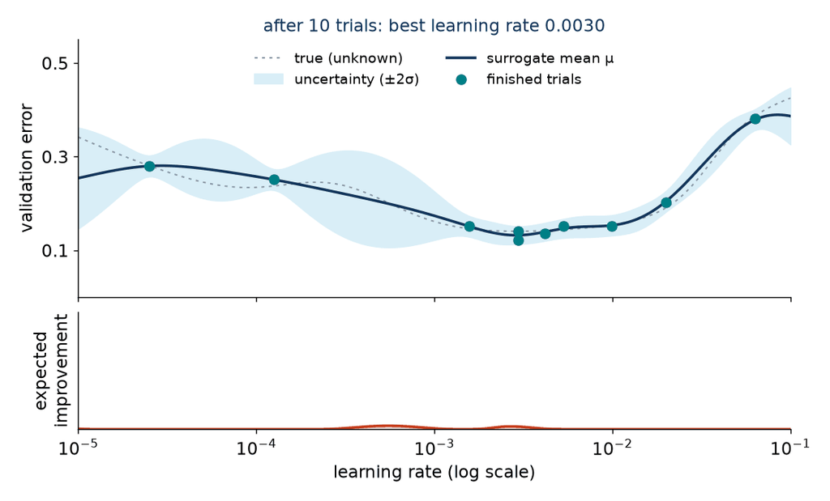

## Optuna’s TPE (Tree-structured Parzen Estimator)

[figure not shown]

1. **Rank** the 30 trials by error. Here the best three (10 %) form the good group.
2. **Densities** of $\mathbf x$ (Parzen = kernel estimate): $l(\mathbf x)$ good, $g(\mathbf x)$ bad
3. **Sample** candidates from $l(\mathbf x)$
4. **Pick** the largest $l(\mathbf x)/g(\mathbf x)$

For improvement over the **split threshold**, EI increases with $l/g$.

**Tree-structured:** a parameter may exist only on one **branch** (`momentum` only if the optimizer is SGD). TPE models each parameter where it is defined; a GP needs a fixed set of dimensions.

[Bergstra et al., NeurIPS 2011](https://papers.nips.cc/paper_files/paper/2011/hash/86e8f7ab32cfd12577bc2619bc635690-Abstract.html)

## Optuna defaults and the leaf study

| Single-objective study | Optuna 5.0 default | Leaf task |
| --- | --- | --- |
| **Sampler** | TPE, 10 startup trials | TPE, 4 startup trials |
| **First trial** | Random setting | Queued baseline |
| **Median pruner** | After 5 completed trials | After 4 completed trials |
| **Warm-up** | 0 steps | First 4 epochs |

After startup, TPE draws **24 candidates**. Its good group contains the best **10%** of trials, rounded up and capped at 25.

## Pruning: stop bad trials early

[figure not shown]

- **Report** validation accuracy after each epoch.
- **Compare** your best accuracy so far with the median accuracy at this epoch in completed trials.
- **Stop** if it falls below that median after warm-up.

The plot uses **error**, so higher is worse.

[Optuna docs: MedianPruner](https://optuna.readthedocs.io/en/stable/reference/generated/optuna.pruners.MedianPruner.html)